# White Wine Quality Between Harmfulness and Benefit By Exploring Physicochemical Properties Data

# Introduction

The aim of this project is describe the physicochemical properties to try specifying which of them affect white wine quality through exploratory data analysis of a dataset containing attributes for 4898 white wine variants. The dataset is related to **“White Wine”** of the Portuguese “Vinho Verde” wine. For more details, consult: http://www.vinhoverde.pt/en/ or the reference [Cortez et al., 2009]. Due to privacy and logistic issues, only physicochemical (inputs) and sensory (the output) variables are available (e.g. there is no data about grape types, wine brand, wine selling price, etc.).

- Number of Instances (obs.): 4898.
- Number of Attributes (variables): 11 + output attribute + serial No (x var.)

# Univariate Data Exploring and Plots Section

```
## [1] 4898   13
```

Our dataset consists of 13 variables, with 4898 observations.

```
## 'data.frame':    4898 obs. of  13 variables:
##  $ X                   : int  1 2 3 4 5 6 7 8 9 10 ...
##  $ fixed.acidity       : num  7 6.3 8.1 7.2 7.2 8.1 6.2 7 6.3 8.1 ...
##  $ volatile.acidity    : num  0.27 0.3 0.28 0.23 0.23 0.28 0.32 0.27 0.3 0.22 ...
##  $ citric.acid         : num  0.36 0.34 0.4 0.32 0.32 0.4 0.16 0.36 0.34 0.43 ...
##  $ residual.sugar      : num  20.7 1.6 6.9 8.5 8.5 6.9 7 20.7 1.6 1.5 ...
##  $ chlorides           : num  0.045 0.049 0.05 0.058 0.058 0.05 0.045 0.045 0.049 0.044 ...
##  $ free.sulfur.dioxide : num  45 14 30 47 47 30 30 45 14 28 ...
##  $ total.sulfur.dioxide: num  170 132 97 186 186 97 136 170 132 129 ...
##  $ density             : num  1.001 0.994 0.995 0.996 0.996 ...
##  $ pH                  : num  3 3.3 3.26 3.19 3.19 3.26 3.18 3 3.3 3.22 ...
##  $ sulphates           : num  0.45 0.49 0.44 0.4 0.4 0.44 0.47 0.45 0.49 0.45 ...
##  $ alcohol             : num  8.8 9.5 10.1 9.9 9.9 10.1 9.6 8.8 9.5 11 ...
##  $ quality             : int  6 6 6 6 6 6 6 6 6 6 ...
```

All the variables are numerical which quantify the chemical properties of the wine, except ‘quality’ variable is integer. At least 3 wine experts rated the quality of each wine, providing a rating between 0 (very bad) and 10 (very excellent). I’ll convert ‘quality’ as a factor variable to help me in exploration. Before that, I’ll remove the the ‘X’ variable because it isn’t needed in my analysis.

```
## 'data.frame':    4898 obs. of  12 variables:
##  $ fixed.acidity       : num  7 6.3 8.1 7.2 7.2 8.1 6.2 7 6.3 8.1 ...
##  $ volatile.acidity    : num  0.27 0.3 0.28 0.23 0.23 0.28 0.32 0.27 0.3 0.22 ...
##  $ citric.acid         : num  0.36 0.34 0.4 0.32 0.32 0.4 0.16 0.36 0.34 0.43 ...
##  $ residual.sugar      : num  20.7 1.6 6.9 8.5 8.5 6.9 7 20.7 1.6 1.5 ...
##  $ chlorides           : num  0.045 0.049 0.05 0.058 0.058 0.05 0.045 0.045 0.049 0.044 ...
##  $ free.sulfur.dioxide : num  45 14 30 47 47 30 30 45 14 28 ...
##  $ total.sulfur.dioxide: num  170 132 97 186 186 97 136 170 132 129 ...
##  $ density             : num  1.001 0.994 0.995 0.996 0.996 ...
##  $ pH                  : num  3 3.3 3.26 3.19 3.19 3.26 3.18 3 3.3 3.22 ...
##  $ sulphates           : num  0.45 0.49 0.44 0.4 0.4 0.44 0.47 0.45 0.49 0.45 ...
##  $ alcohol             : num  8.8 9.5 10.1 9.9 9.9 10.1 9.6 8.8 9.5 11 ...
##  $ quality             : Factor w/ 7 levels "3","4","5","6",..: 4 4 4 4 4 4 4 4 4 4 ...
```

```
##  fixed.acidity    volatile.acidity  citric.acid     residual.sugar
##  Min.   : 3.800   Min.   :0.0800   Min.   :0.0000   Min.   : 0.600
##  1st Qu.: 6.300   1st Qu.:0.2100   1st Qu.:0.2700   1st Qu.: 1.700
##  Median : 6.800   Median :0.2600   Median :0.3200   Median : 5.200
##  Mean   : 6.855   Mean   :0.2782   Mean   :0.3342   Mean   : 6.391
##  3rd Qu.: 7.300   3rd Qu.:0.3200   3rd Qu.:0.3900   3rd Qu.: 9.900
##  Max.   :14.200   Max.   :1.1000   Max.   :1.6600   Max.   :65.800
##
##    chlorides       free.sulfur.dioxide total.sulfur.dioxide
##  Min.   :0.00900   Min.   :  2.00      Min.   :  9.0
##  1st Qu.:0.03600   1st Qu.: 23.00      1st Qu.:108.0
##  Median :0.04300   Median : 34.00      Median :134.0
##  Mean   :0.04577   Mean   : 35.31      Mean   :138.4
##  3rd Qu.:0.05000   3rd Qu.: 46.00      3rd Qu.:167.0
##  Max.   :0.34600   Max.   :289.00      Max.   :440.0
##
##     density             pH          sulphates         alcohol
##  Min.   :0.9871   Min.   :2.720   Min.   :0.2200   Min.   : 8.00
##  1st Qu.:0.9917   1st Qu.:3.090   1st Qu.:0.4100   1st Qu.: 9.50
##  Median :0.9937   Median :3.180   Median :0.4700   Median :10.40
##  Mean   :0.9940   Mean   :3.188   Mean   :0.4898   Mean   :10.51
##  3rd Qu.:0.9961   3rd Qu.:3.280   3rd Qu.:0.5500   3rd Qu.:11.40
##  Max.   :1.0390   Max.   :3.820   Max.   :1.0800   Max.   :14.20
##
##  quality
##  3:  20
##  4: 163
##  5:1457
##  6:2198
##  7: 880
##  8: 175
##  9:   5
```

After deleting ‘X’ variable (which is just an index) our dataset consists of 12 variables, with 4898 observations.

**Hint 1:** The variables which I think they are the most variables affecting the ‘quality’ will have the blue histograms in this section.

**Hint 2:** In this analysis, I calculated outliers which are bigger than “Q3 + (1.5(IQR))” and smaller than “Q1 - (1.5 (IQR))” and I will use this calculations next in all variables. Now, let’s start.

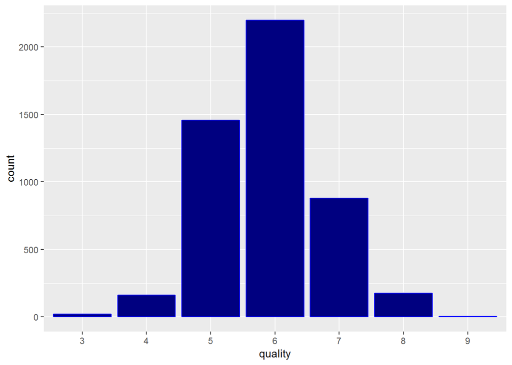

```
##
##    3    4    5    6    7    8    9
##   20  163 1457 2198  880  175    5
```

**The main variable ‘quality’:** I used bar plot because it is suitable for visualizing ‘quality’ as Factor/Categorical variable. Quality score is between (0 and 10) and the values range between 3 as minimum and 9 as maximum score. There are no observations in scores 1, 2 and 10. Most wine is in 6 score and the is least in 9 score. The wine evaluations (quality scores) are concentrated in three columns (5, 6 and 7).

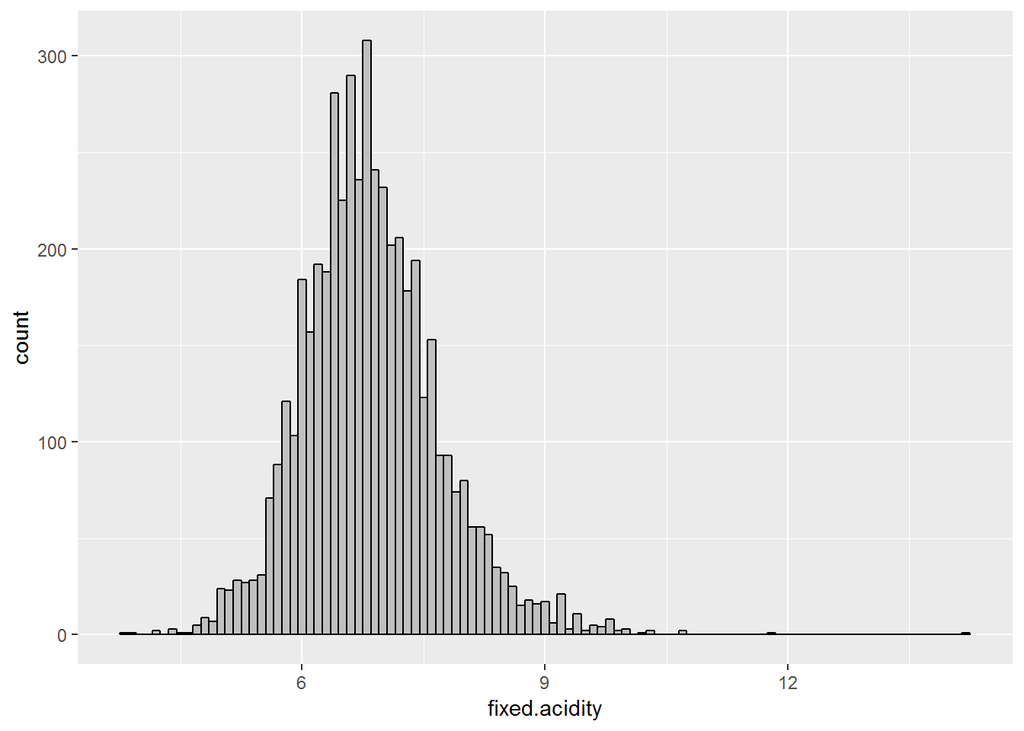

```
##    Min. 1st Qu.  Median    Mean 3rd Qu.    Max.
##   3.800   6.300   6.800   6.855   7.300  14.200
```

**Fixed acidity (Tartaric acid - g/dm^3):** Most acids involved in wine are fixed or nonvolatile (do not evaporate readily). The fixed acidity follows a normal distribution with mean 6.855 (the median 6.800 g/dm^3) and some outliers found over 8.8 and under 4.8. 75% of wine is below 7.3 g/dm^3.

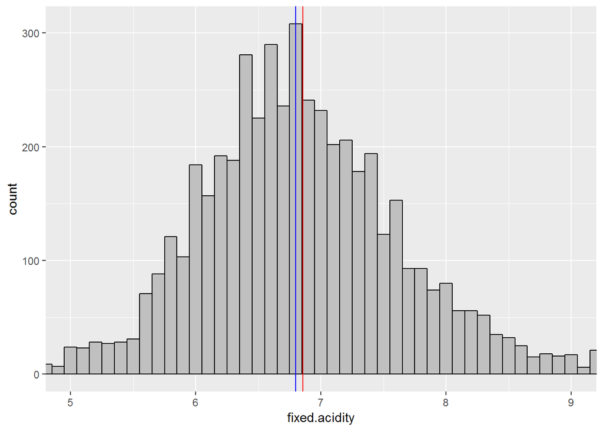

The plot got more readable by removing some outliers in the right side of the plot. Now, The histogram looks like approximately normal distribution.

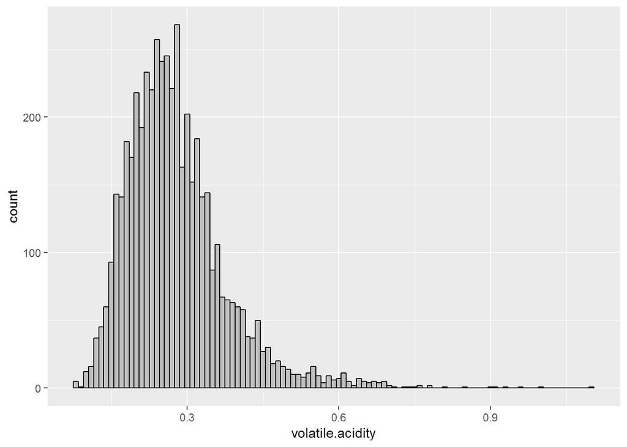

```
##    Min. 1st Qu.  Median    Mean 3rd Qu.    Max.
##  0.0800  0.2100  0.2600  0.2782  0.3200  1.1000
```

**Volatile acidity (Acetic acid - g/dm^3):** The amount of acetic acid in wine, which at too high levels can **lead to an unpleasant, vinegar taste.** The volatile acidity has some outliers over 0.49 and under 0.05. The 75% of the data is below 0.32 g/dm^3.

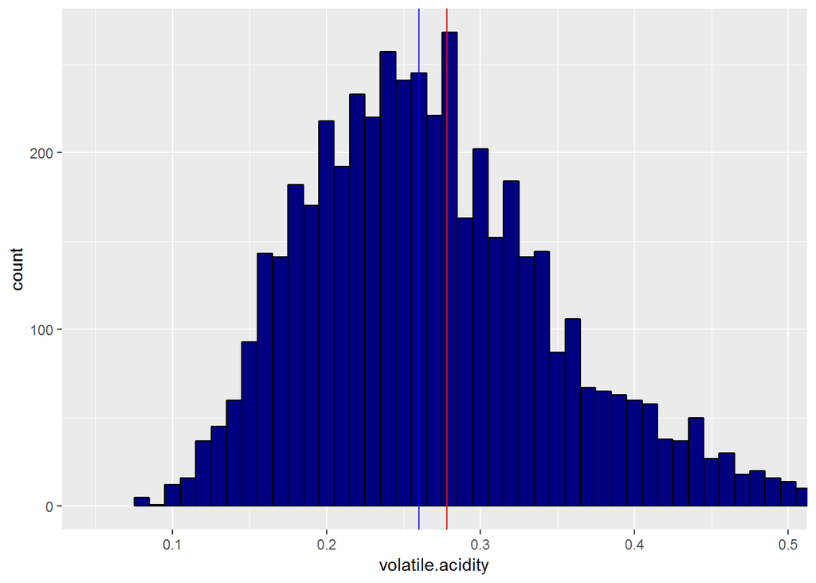

The trimmed volatile acidity distribution appears right skewed with mean in 0.28 g/dm^3.

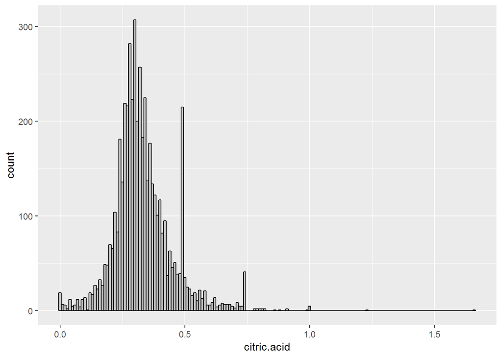

```
##    Min. 1st Qu.  Median    Mean 3rd Qu.    Max.
##  0.0000  0.2700  0.3200  0.3342  0.3900  1.6600
```

**Citric acid** found in small quantities (0, 1 g/dm^3), citric acid can **add freshness and flavor to wines.** Outliers are found over 0.57 g/dm^3 and under 0.09 g/dm^3 and unusual spikes in 0.5 and 0.75 g/dm^3. I’ll zoom in.

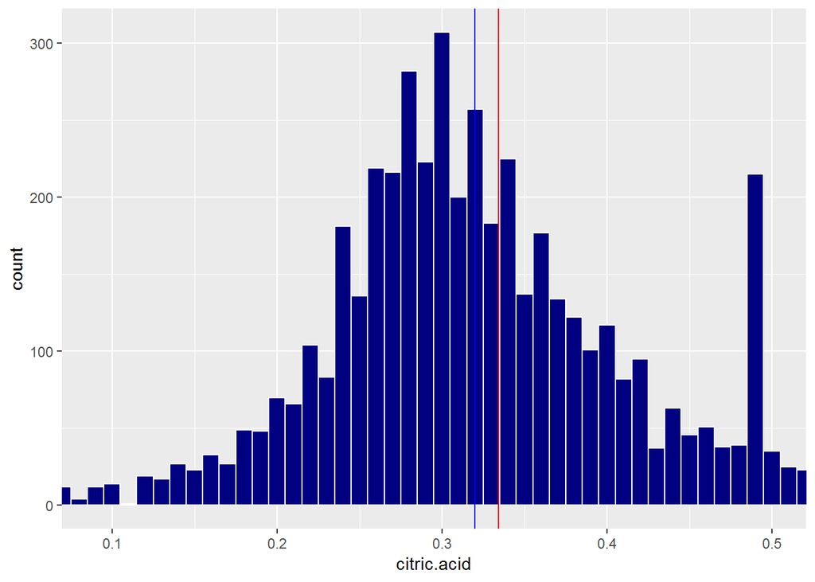

The trimmed Citric acid looks approximately normal distribution with unusual peak in 0.49 g/dm^3, we can consider it as anomaly.

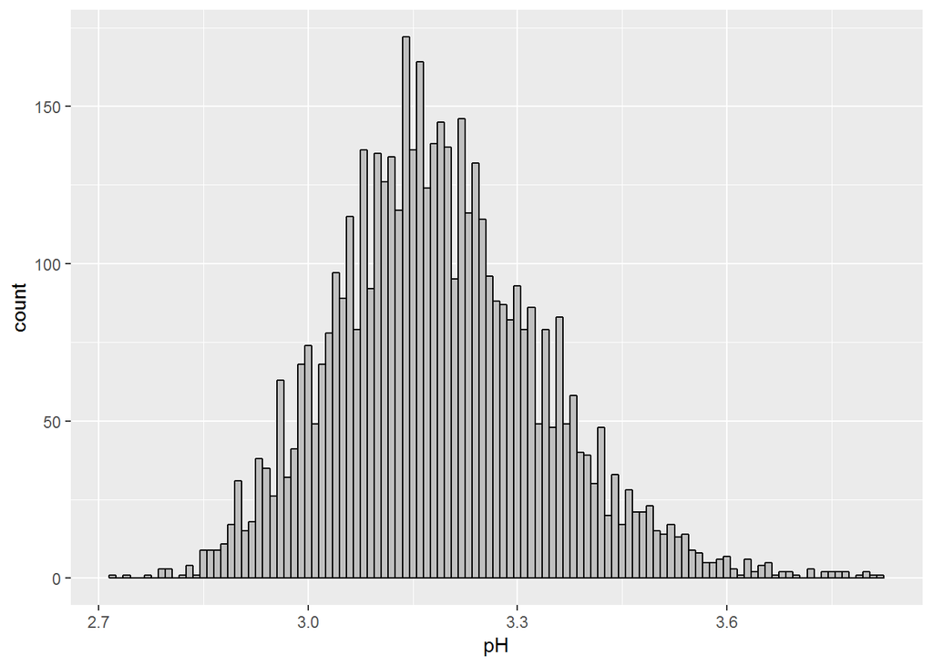

```
##    Min. 1st Qu.  Median    Mean 3rd Qu.    Max.
##   2.720   3.090   3.180   3.188   3.280   3.820
```

**pH:** describes how **acidic or basic a wine** is on a scale from 0 (very acidic) to 14 (very basic); most wines are between 3 - 4 on the pH scale. It means moderately acidic. Outliers are found over 3.565 and under 2.805 and maximum acidic level is 3.82.

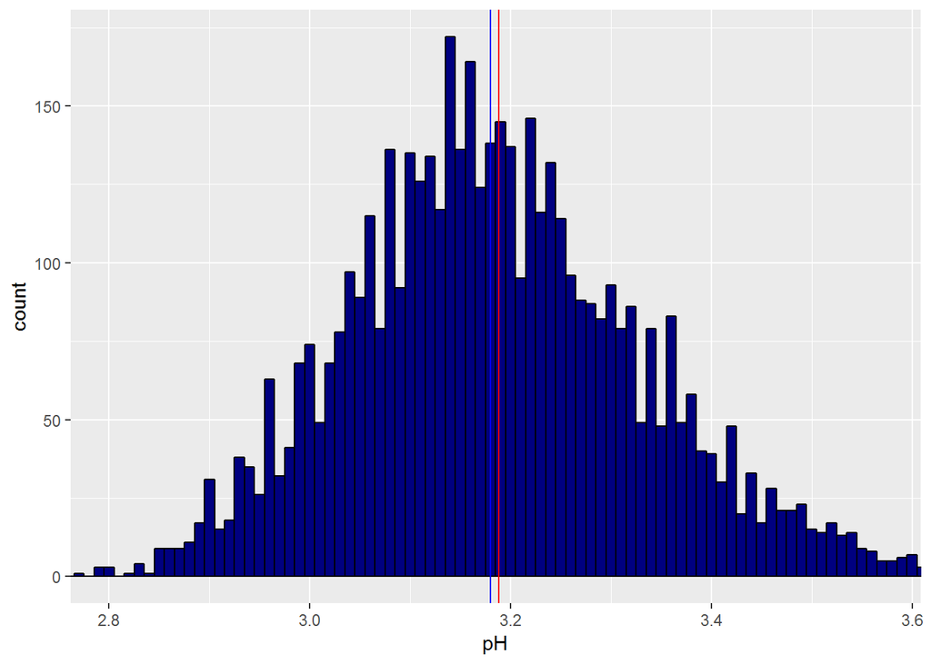

The histogram is skewed a little bit to right but it is nearly normal with mean 3.188 and median 3.180.

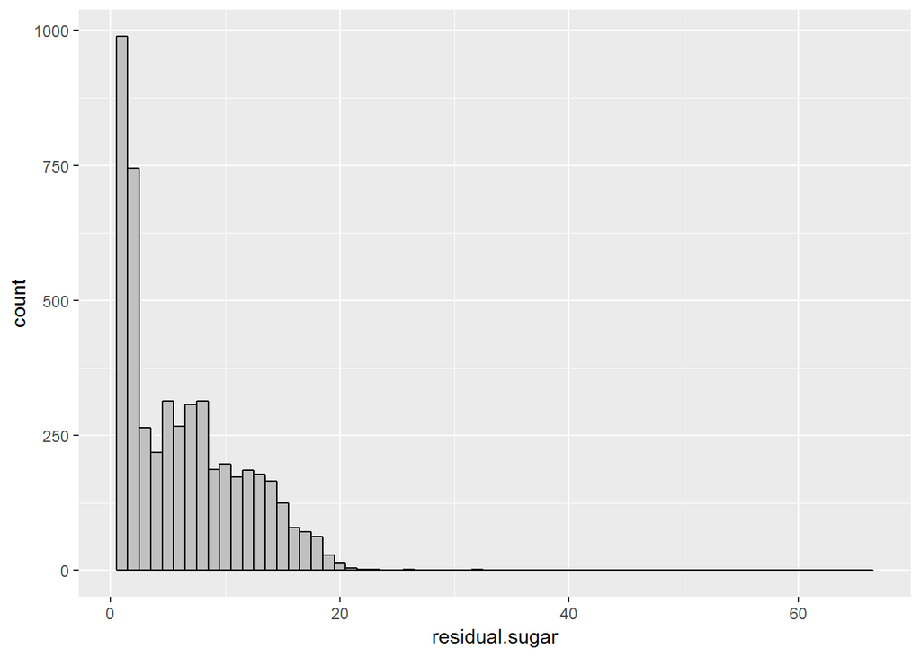

**Residual sugar:** The amount of **sugar remaining** after fermentation stops, it’s rare to find wines with less than 1 g/liter (g/dm^3) and wines with greater than 45 g/L are considered sweet. Most wine lie in 1 and 20 g/dm^3. Outliers are found in 23, 26, 32 and 66. let’s remove outliers ..

```
##    Min. 1st Qu.  Median    Mean 3rd Qu.    Max.
##   0.600   1.700   5.200   6.391   9.900  65.800
```

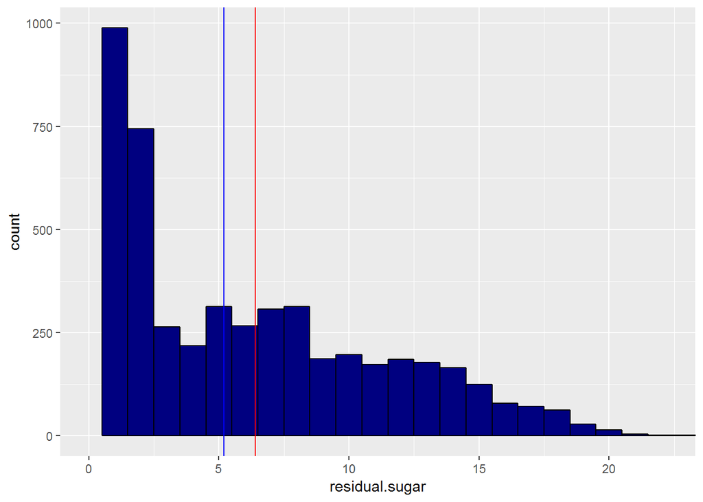

Residual sugar is skewed to the right, with mean 6.39 g/dm^3 and the median 5.2 g/dm^3 which resisted outliers to represent true medium value. Most wine are in 1 and 2 g/dm^3. Here I used ‘xlim’ to remove outliers but it doesn’t show clearly the difference between the peaks so I’ll transform the x axis of to log10 to explore the data by zooming it and trim the long tail.

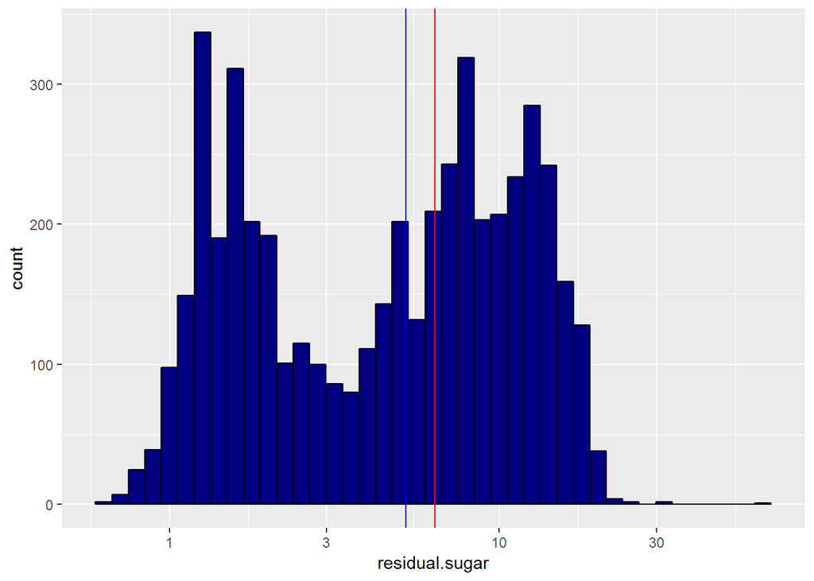

The transformed distribution appears bi-modal with the peaks at (around 2 and again around 8 g/dm^3).

Here I used the log10 of residual sugar rather than using limiting to focus on the distribution of the small values of data (from 0 to about 20).

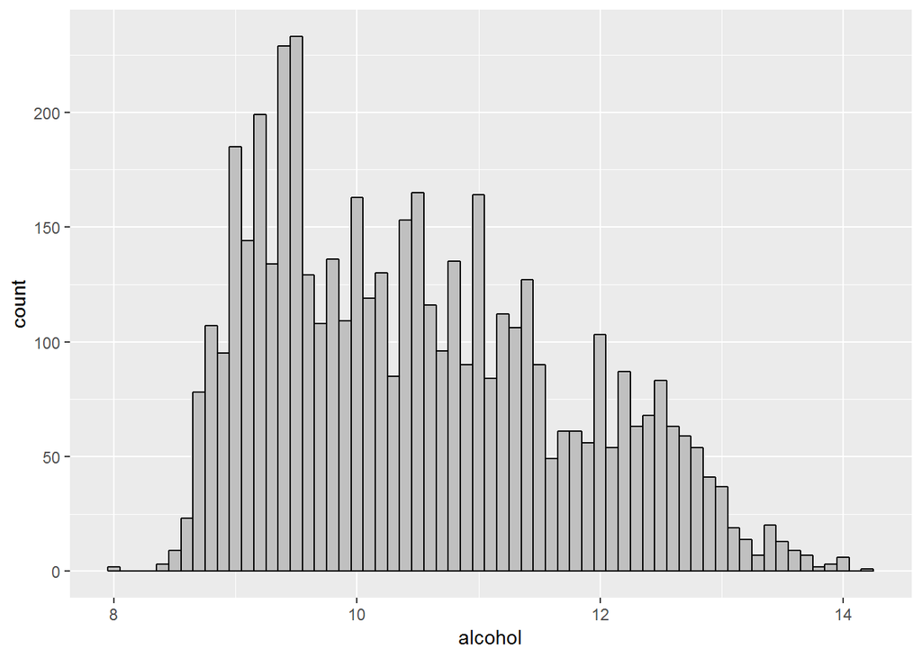

```
##    Min. 1st Qu.  Median    Mean 3rd Qu.    Max.
##    8.00    9.50   10.40   10.51   11.40   14.20
```

**Alcohol:** the percent alcohol content of the wine. The range is between 8% as minimum and 14.2% as maximum.

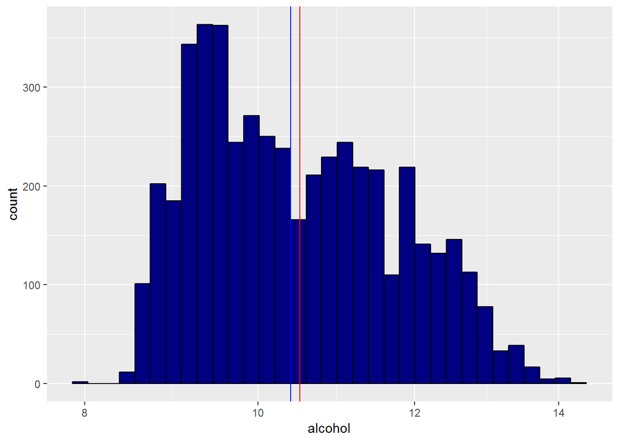

The histogram is clearly skewed to right with mean 10.51% and median 10.4 %.

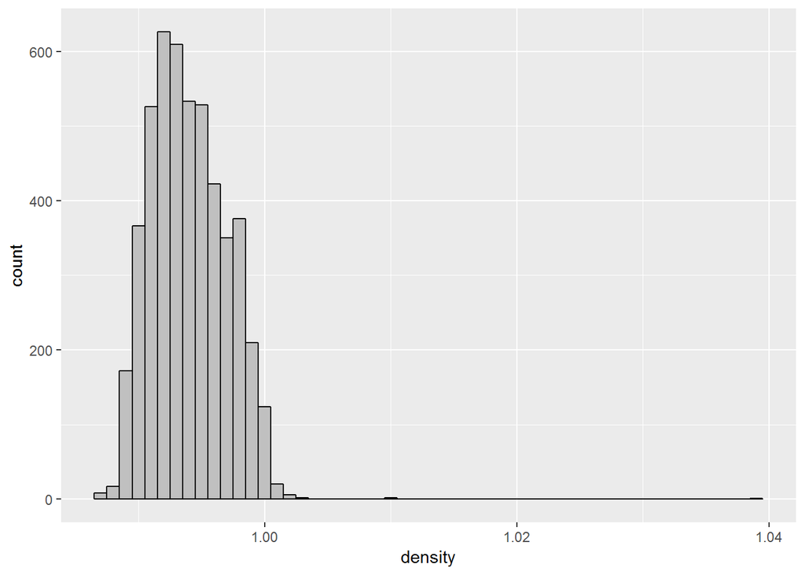

```
##    Min. 1st Qu.  Median    Mean 3rd Qu.    Max.
##  0.9871  0.9917  0.9937  0.9940  0.9961  1.0390
```

**The density of water** is close to that of water depending on the percent alcohol and sugar content. Some outliers in 1.01 and 1.039 g/cm^3 (g / cm^3 = 1000 g/dm^3) using Google. Let’s trim it.

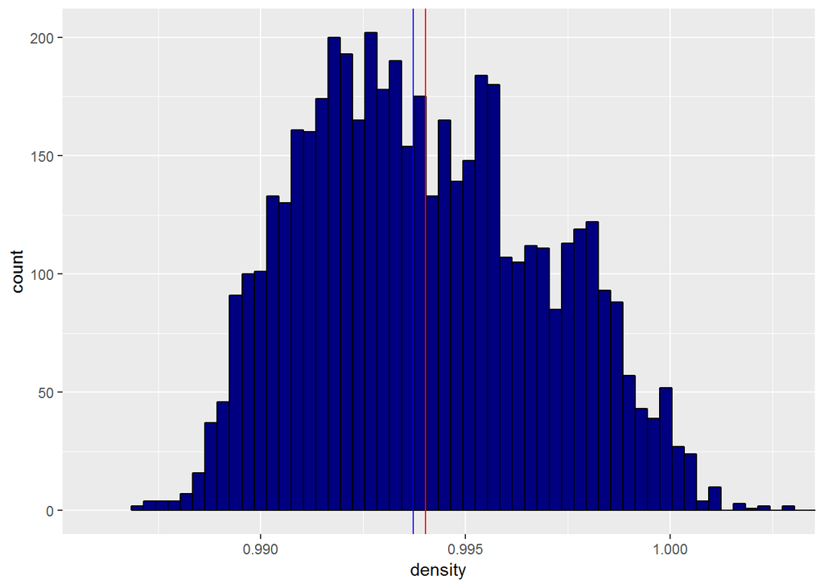

The shape appears as slightly right skewed distribution with mean equal 0.994 g/cm^3 and median 0.9937 g/cm^3.

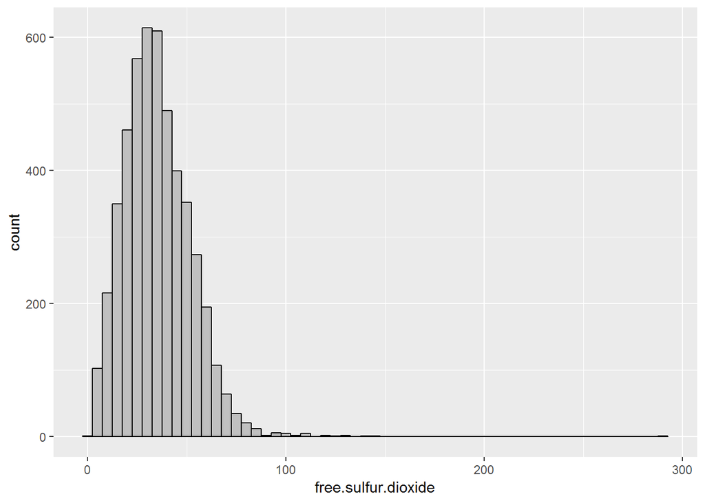

```
##    Min. 1st Qu.  Median    Mean 3rd Qu.    Max.
##    2.00   23.00   34.00   35.31   46.00  289.00
```

**Free sulfur dioxide:** The free form of SO2 exists in equilibrium between molecular SO2 (as a dissolved gas) and bisulfite ion; **it advances microbial growth and the oxidation of wine.** It has many outliers from 85 to 289 mg/dm^3 as a maximum value. Let’s trim it.

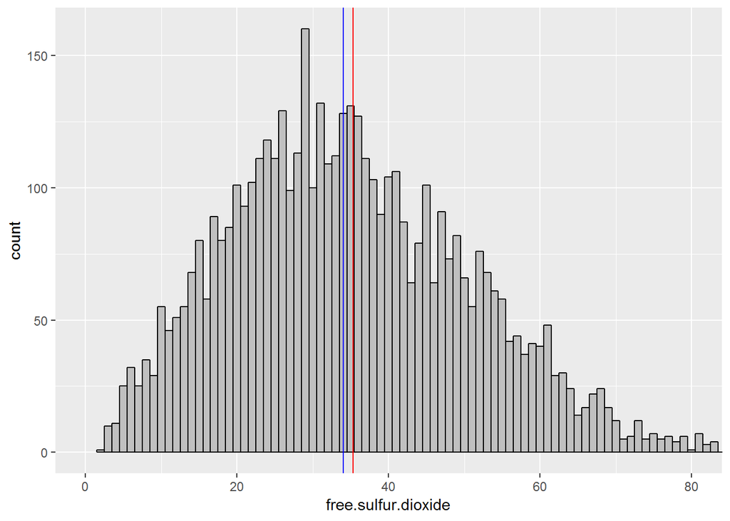

It is slightly right skewed but approximately normal and one peak at 29 mg/dm^3 (0.029 g/dm^3).

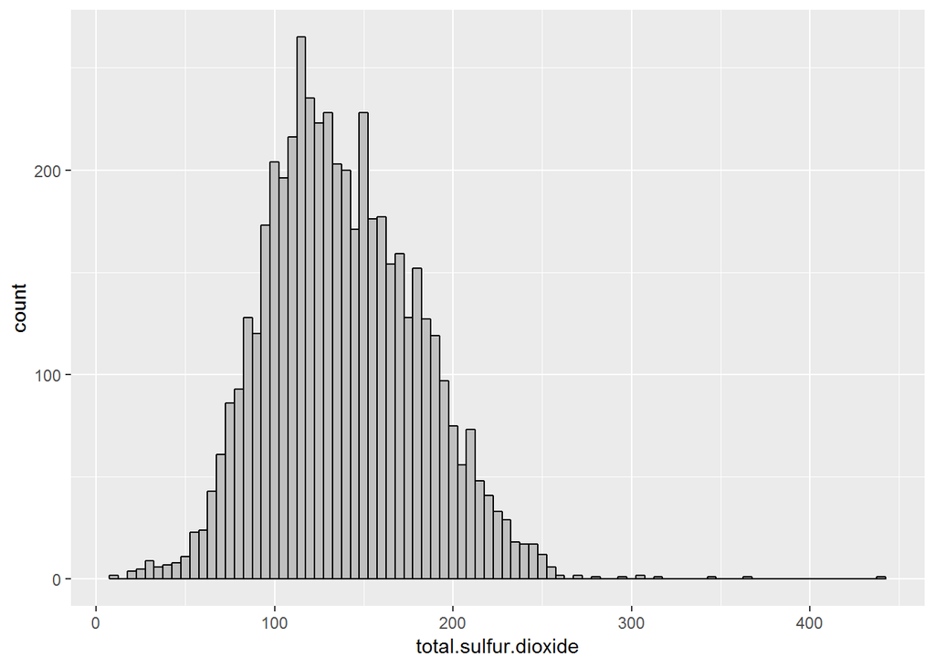

```
##    Min. 1st Qu.  Median    Mean 3rd Qu.    Max.
##     9.0   108.0   134.0   138.4   167.0   440.0
```

```
##    Mode   FALSE    TRUE
## logical    4852      46
```

**Total sulfur dioxide** is amount of free and bound forms of S02; in low concentrations, SO2 is mostly undetectable in wine, but at free SO2 concentrations over 50 ppm (1 ppm = 1 mg/dm^3) using Google, SO2 becomes evident in the nose and taste of wine. I found 46 of wine less than 50 ppm, So I asked, if SO2 becomes clear in smell and taste, is this good quality or bad quality of wine? It has many outliers greater than 255 and below 19 mg/dm^3, with maximum 440 and minimum 9 mg/dm^3.

**Hint:** (According to Wikipedia article) In recent studies white wine (which contains high levels of Sulfur dioxide) was indicated to have some cardiovascular benefits and this makes me excited to investigate the effect of Sulfur dioxide levels (which is considered **a health criterion**) on ‘quality’ of wine. We’ll see.

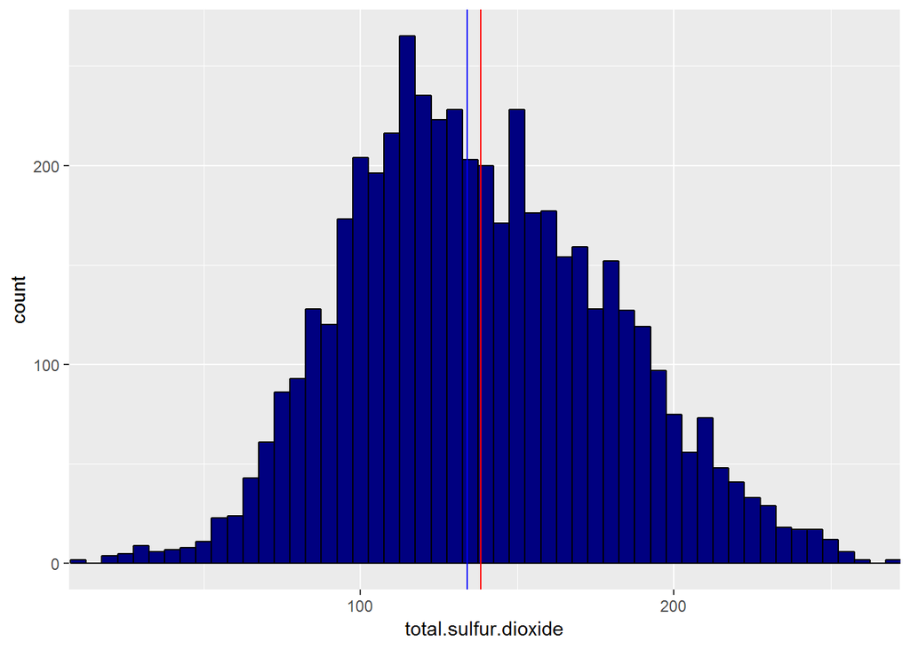

After trimming the plot of total sulfur dioxide, it appears slightly right skewed with the mean at 138.4 and median at 134 mg/dm^3.

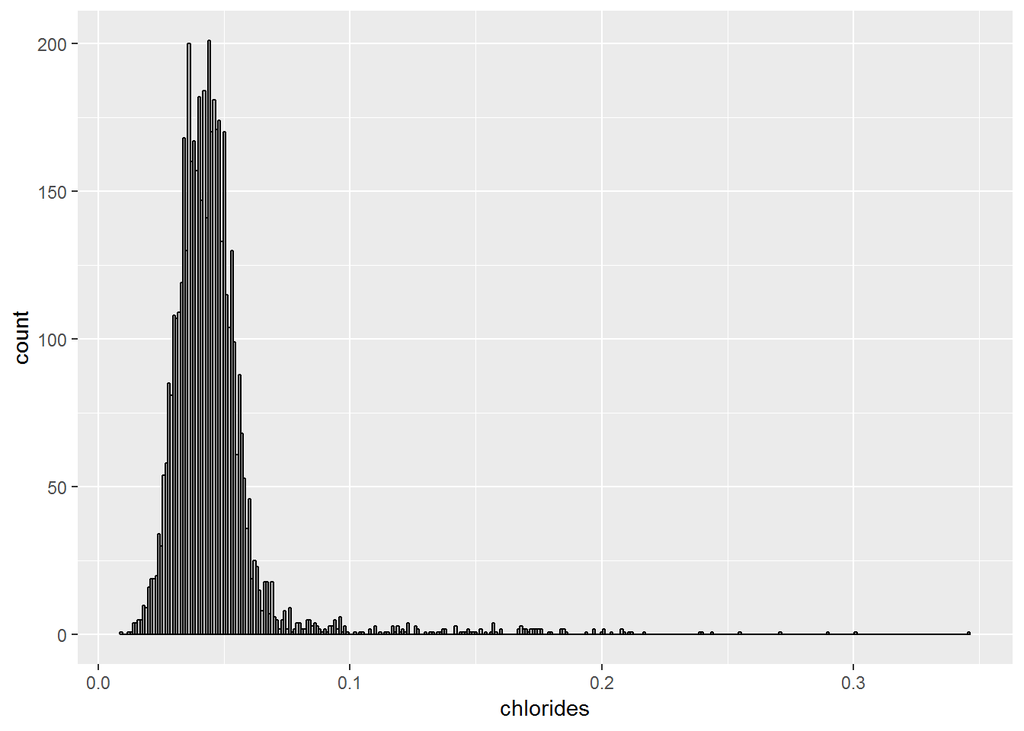

```
##    Min. 1st Qu.  Median    Mean 3rd Qu.    Max.
## 0.00900 0.03600 0.04300 0.04577 0.05000 0.34600
```

**Chlorides (Sodium Chloride)** is the amount of **salt** in the wine (g/dm^3). It has many outliers greater than 0.071 and less than 0.015, with maximum 0.35 and minimum 0.009 g/dm^3. Let’s trim it.

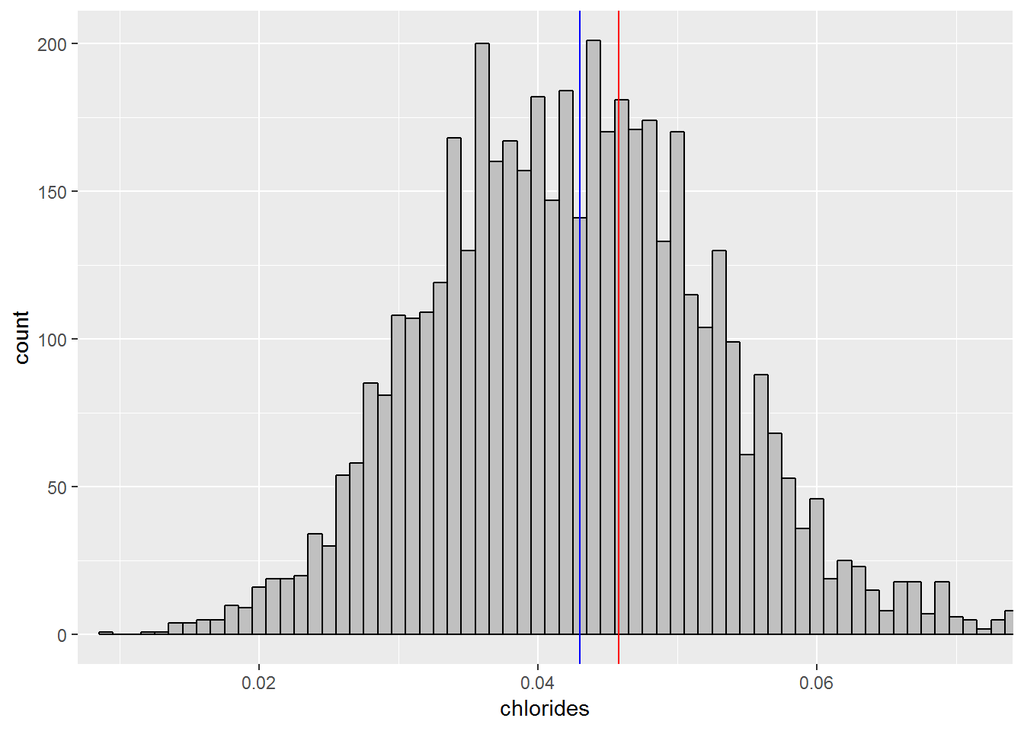

After adjusting x axis from 0.01 to 0.071, Chlorides follows approximately normal but a little right skewed distribution, with max two values at 0.036 and 0.044 g/dm^3 and the median is 0.043 g/dm^3.

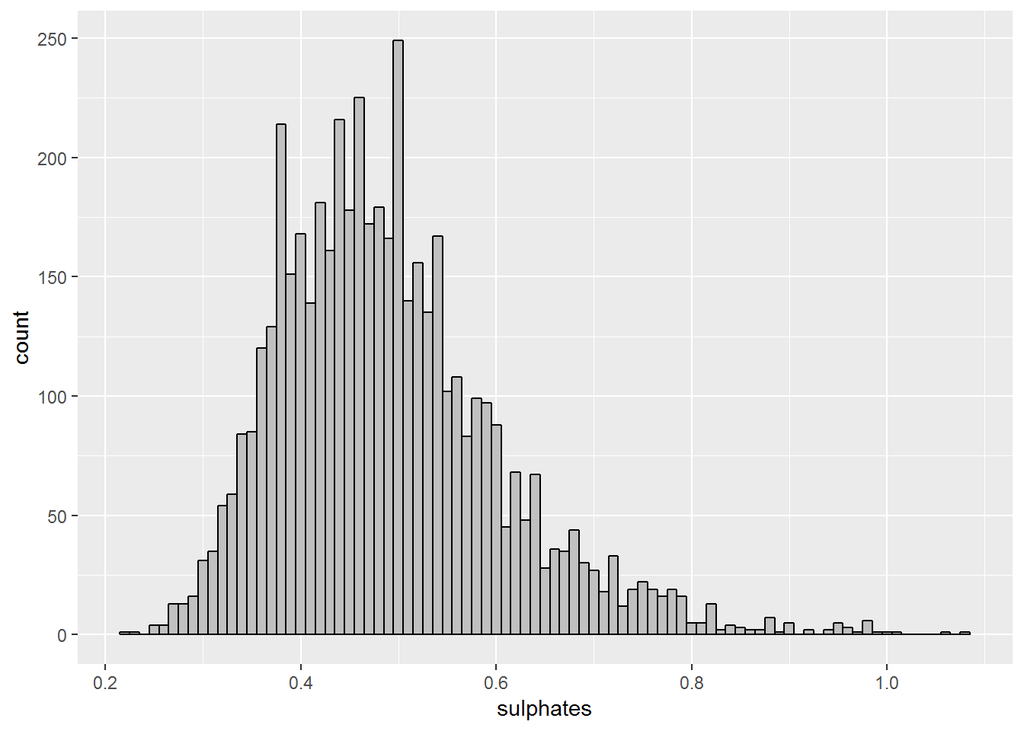

```
##    Min. 1st Qu.  Median    Mean 3rd Qu.    Max.
##  0.2200  0.4100  0.4700  0.4898  0.5500  1.0800
```

**Sulphates (potassium sulphate):** A wine additive which can contribute to sulfur dioxide gas (S02) levels, which acts as an antimicrobial and antioxidant. The distribution range between 0.22 and 1.08 g/dm^3, and it has outliers upper 0.76 and below 0.2. I’ll trim it.

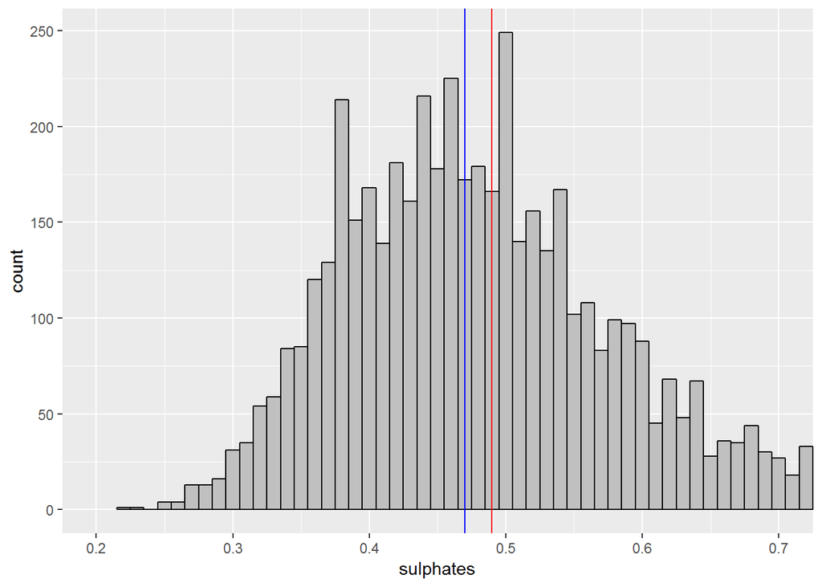

The histogram is slightly right skewed with mean 0.48 and median 0.47 g/dm^3.

# Univariate Analysis

### What is the structure of your dataset?

This dataset contains 4,898 records of white wine data with 12 variables, 11 input variables based on physicochemical properties which affect wine quality and 1 output variable which is the quality of the wine. At least 3 wine experts rated the quality of each wine, providing a rating between 0 (very bad) and 10 (very excellent).

### What is/are the main feature(s) of interest in your dataset?

I think ‘quality’ is the main feature in this dataset because it is a criterion of wine goodness. I want to check all the other variables combinations, which of them are affecting the ‘quality’ the most. Quality scores (between 0 and 10) values range (in the dataset) between 3 as minimum and 9 as maximum score. There are no observations in scores 1, 2 and 10. Most frequent ‘quality’ score is in 6 score and the least frequent is in 9 score. Since the most frequent ‘quality’ scores are in the three columns (5, 6 and 7) in the middle, does this indicate that the ‘quality’ evaluation is based on the experts opinions of taste and smell? Or on a specific technical basis depending on the physical or chemical properties of the wine?. So, this is what I will investigate in the next section.

### What other features in the dataset do you think will help support your investigation into your feature(s) of interest?

I want to investigate the two variables (residual sugar and alcohol) because I read about them that they are affecting the ‘quality’ of wine and I observed that they have clearly different distributions than the other variables. Also I want to do more investigations on some variables (Total Sulfur dioxide, Density, Volatile acidity, Citric acid and pH) which I think they are important for their influence (smell and taste) on wine quality.

### Did you create any new variables from existing variables in the dataset?

I didn’t need to create any new variables.

### Of the features you investigated, were there any unusual distributions? Did you perform any operations on the data to tidy, adjust, or change the form of the data? If so, why did you do this?

I converted ‘quality’ column as a factor variable to help me in exploration. When plotting histograms of the variables, I applied the ‘xlim’ to limit the lower and upper x-axis value to remove outliers and to focus on the main values for better visualizations and to see clearer distributions of these variables. Also, I log-transformed the right skewed ‘Residual Sugar’ distribution to zoom in the small values of data.

# Bivariate Plots Section

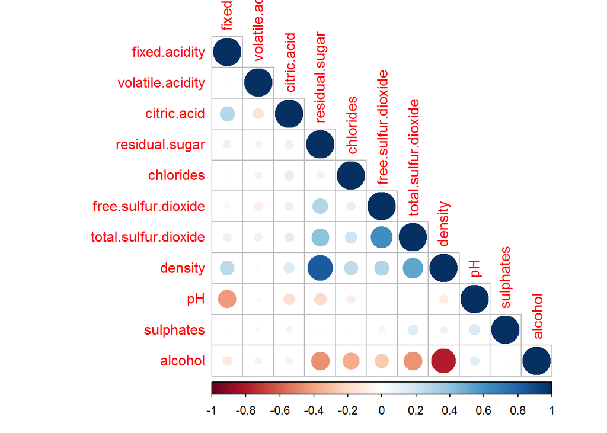

The correlation matrix shows interesting relations between (residual.sugar vs density) and (alcohol vs density), also between (residual sugar and alcohol). This gives me a hint that I should try (residual.sugar, alcohol & density) as a combination in Multi-variate analysis. I will also check acidity related variables (pH, fixed.acidity and volatile.acidity) vs the other variables to determine the over all effect of acidity on the other variables.

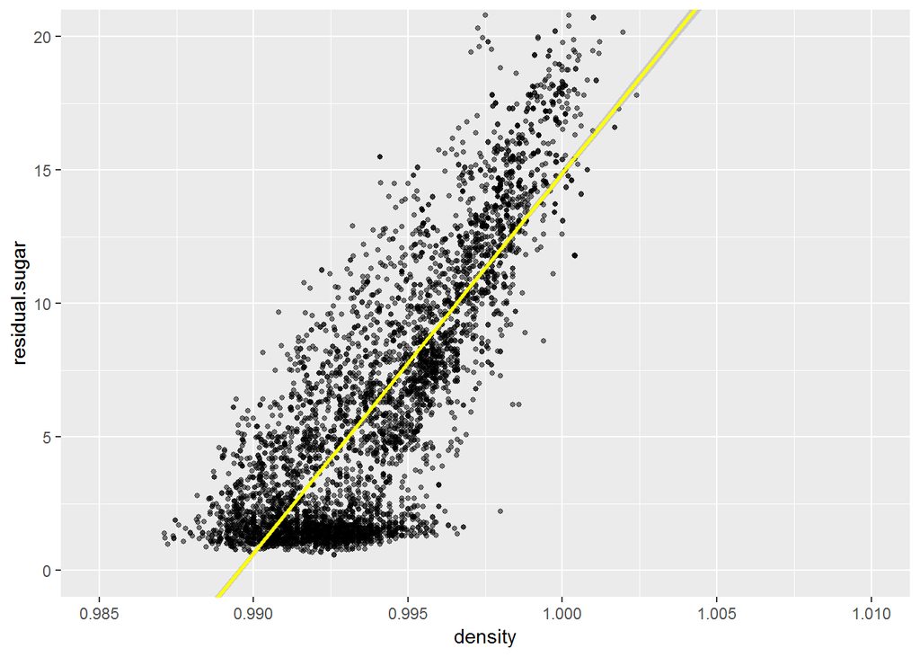

```
##
##  Pearson's product-moment correlation
##
## data:  white_wine$density and white_wine$residual.sugar
## t = 107.87, df = 4896, p-value < 2.2e-16
## alternative hypothesis: true correlation is not equal to 0
## 95 percent confidence interval:
##  0.8304732 0.8470698
## sample estimates:
##       cor
## 0.8389665
```

I found strong positive correlation (+0.84) between density and residual.sugar

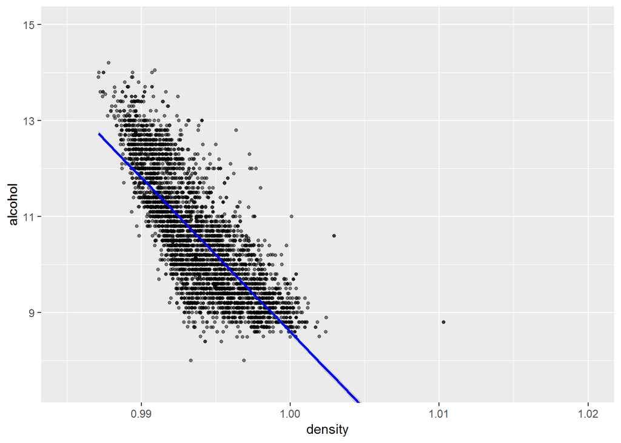

```
##
##  Pearson's product-moment correlation
##
## data:  white_wine$density and white_wine$alcohol
## t = -87.255, df = 4896, p-value < 2.2e-16
## alternative hypothesis: true correlation is not equal to 0
## 95 percent confidence interval:
##  -0.7908646 -0.7689315
## sample estimates:
##        cor
## -0.7801376
```

Strong positive correlation (about 0.8) is between (density and residual.sugar) but Strong negative correlation about 0.8 is between density and alcohol, It makes sense, considering the fermentation process of wine, the sugar is consumed to produce alcohol. And since the residual sugar is more denser than alcohol (shown above). The inverse relation presented and negative moderate correlation (-0.45), as shown next.

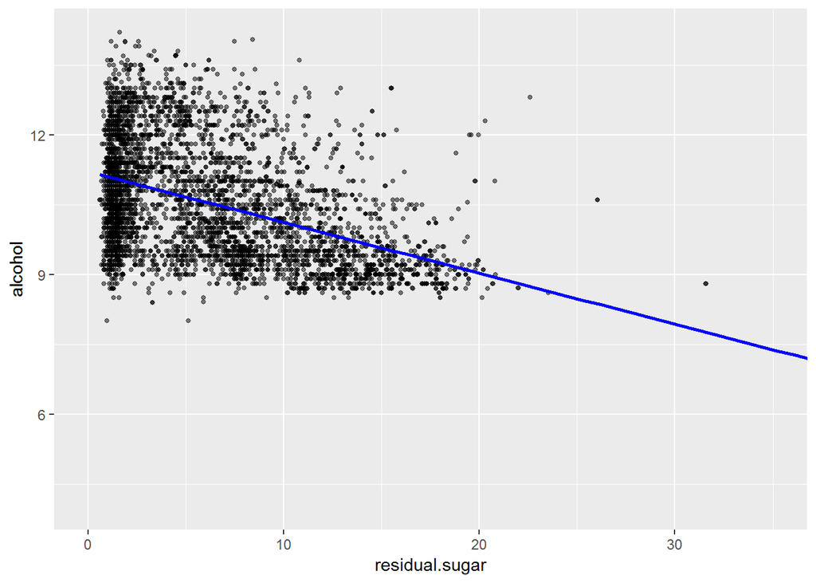

```
##
##  Pearson's product-moment correlation
##
## data:  white_wine$residual.sugar and white_wine$alcohol
## t = -35.321, df = 4896, p-value < 2.2e-16
## alternative hypothesis: true correlation is not equal to 0
## 95 percent confidence interval:
##  -0.4726723 -0.4280267
## sample estimates:
##        cor
## -0.4506312
```

Now, what is the relation between each of these three variables (residual.sugar, alcohol and density) with ‘quality’

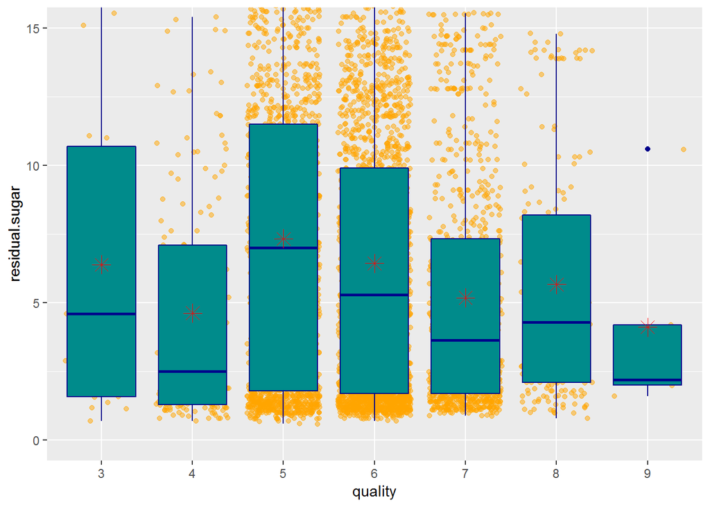

```
##
##    3    4    5    6    7    8    9
##   20  163 1457 2198  880  175    5
```

Residual sugar is the variable with the negative correlation with ‘quality’ except grades 3 and 4 may be because as shown in the last cell the number of data samples in (3, 4, 8 & 9) are too small compared with (5, 6 & 7) **so** **(5, 6 & 7) may be good representatives of the main trend of these scores.**

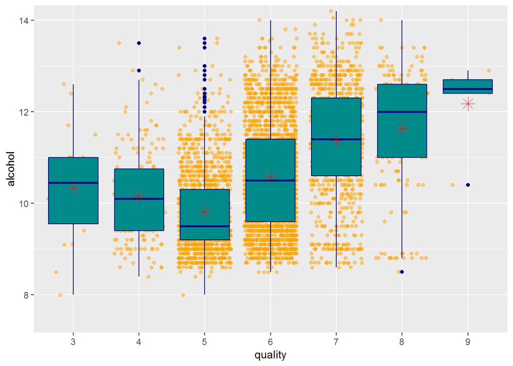

```
## white_wine$quality: 3
##    Min. 1st Qu.  Median    Mean 3rd Qu.    Max.
##    8.00    9.55   10.45   10.35   11.00   12.60
## --------------------------------------------------------
## white_wine$quality: 4
##    Min. 1st Qu.  Median    Mean 3rd Qu.    Max.
##    8.40    9.40   10.10   10.15   10.75   13.50
## --------------------------------------------------------
## white_wine$quality: 5
##    Min. 1st Qu.  Median    Mean 3rd Qu.    Max.
##   8.000   9.200   9.500   9.809  10.300  13.600
## --------------------------------------------------------
## white_wine$quality: 6
##    Min. 1st Qu.  Median    Mean 3rd Qu.    Max.
##    8.50    9.60   10.50   10.58   11.40   14.00
## --------------------------------------------------------
## white_wine$quality: 7
##    Min. 1st Qu.  Median    Mean 3rd Qu.    Max.
##    8.60   10.60   11.40   11.37   12.30   14.20
## --------------------------------------------------------
## white_wine$quality: 8
##    Min. 1st Qu.  Median    Mean 3rd Qu.    Max.
##    8.50   11.00   12.00   11.64   12.60   14.00
## --------------------------------------------------------
## white_wine$quality: 9
##    Min. 1st Qu.  Median    Mean 3rd Qu.    Max.
##   10.40   12.40   12.50   12.18   12.70   12.90
```

Alcohol is the variable with positive correlation with ‘quality’. Wines with scores 3 and 4 are going against the trend may be because there are too small number of data examples in scores (3 and 4) so it is hard to capture a trend from them.

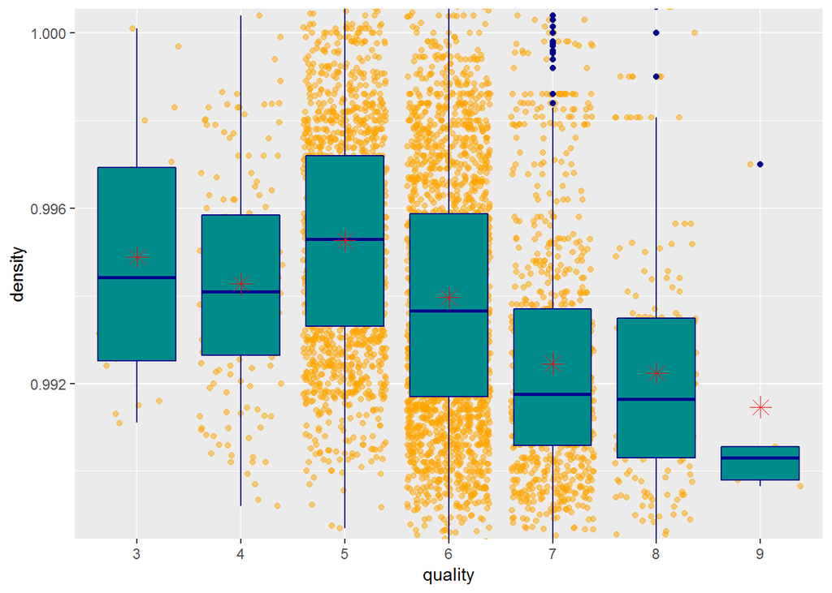

Here clear negative correlation between ‘quality’ and ‘density’ is shown. This correlation is expected as (density & residual.sugar) are strongly positively correlated and both of them is negatively correlated with ‘quality’.

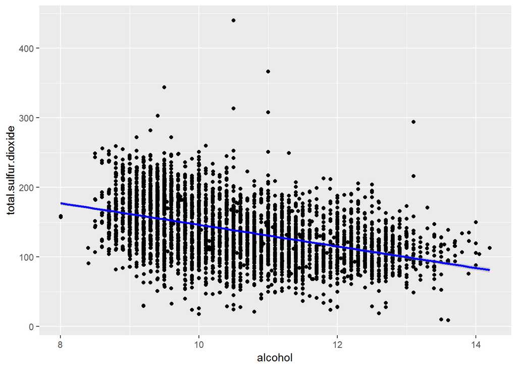